# Exam Scores with Individual Differences

Lee & Wagenmakers Part II. 6.2, p79

cn

2023-04-10

```r
set.seed(12345)

if (!require("pacman", quietly = TRUE)) install.packages("pacman")
pacman::p_load(tidyverse, cowplot, psych, R2jags)
pacman::p_load_gh("RLesur/klippy", "rpruim/CalvinBayes")
klippy::klippy()
```

# 1 Graphic model

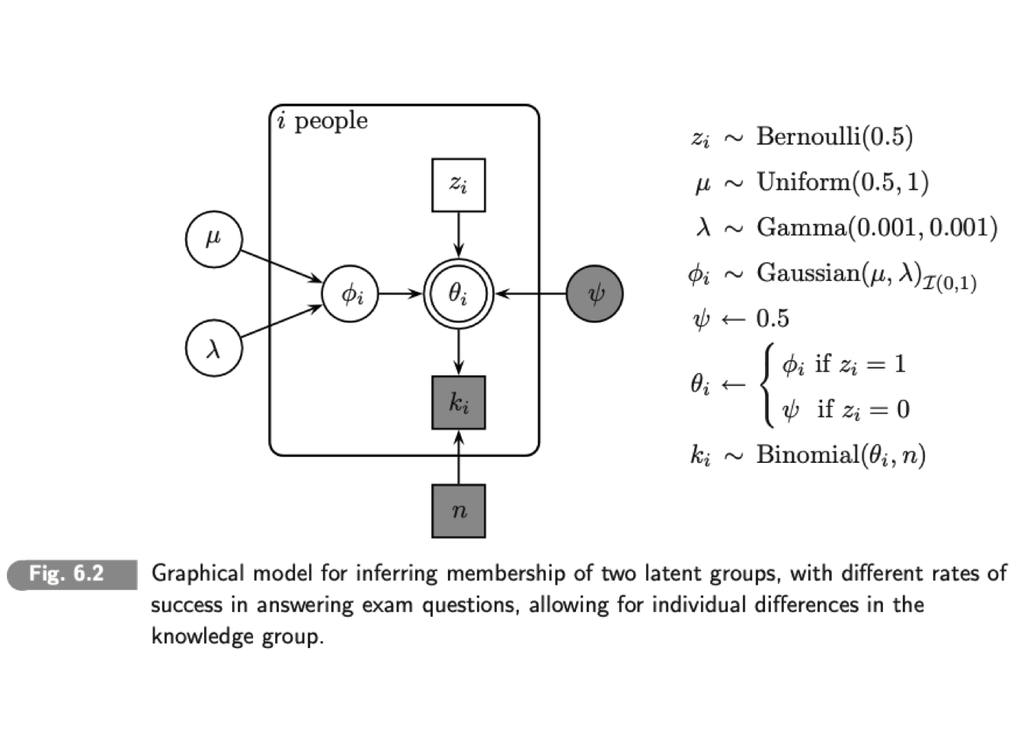

# 2 Main data

## 2.1 Model

```r
k <- c(21,17,21,18,22,31,31,34,34,35,35,36,39,36,35)
p <- length(k) #number of people
n <- 40 # number of questions

data <- list("p", "k", "n") # to be passed on to JAGS
myinits <-  list(
  list(mu = 0.75, lambda = 1, z = round(runif(p)),
       muprior = 0.75, lambdaprior = 1)) # Initial group assignment

# parameters to be monitored:
parameters <- c("predphi","phi","theta","z","mu","sigma","priorpredphi")
```

‘Exams_1.txt’(6.1)과 비교할 때, 파라미터 목록에 `phi` 가 없고, 대신에 `theta`가 있다. 8~15번 참가의 `phi`와 `theta`는 같기 때문이다. 원래 코드에는 파라미터 목록에 `phi` 가 없지만, 확인을 위해 위에 추가하였다.

모델 파일이 두 개인데 `Exam_2.txt`는 sensoring에 `I()`을 쓰고, `Exam_2J.txt`는 truncation `T()`을 쓴다. Part II. 5.5, 70쪽 **Censored Data(차사순 할머니 자료)**와 같은 상황이다. `Exam_2.txt`는 오류나서, 아래는 `Exam_2J.txt` 모델을 적었다.

참고로, 단락 **6.6**에는 개인차를 모델링하기 위해 `Gaussian`을 sensoring하는 대신 0과 1사이에 정의된`Beta` 분포가 더 낫다고 설명한다. 또한 `WinBUGS`에 비해 `JAGS`가 censoring과 truncation을 더 정확히 구분한다고 설명한다(**90쪽 각주** 참조)

```r
model_text <- "
# Exam Scores With Individual Differences
model{
  # Each Person Belongs To One Of Two Latent Groups
  for (i in 1:p){
    z[i] ~ dbern(0.5)
  }

  # First Group Guesses
  psi <- 0.5

  # The Second Group Allows Individual Differences
  for (i in 1:p){
    # Second Group Drawn From A Censored Gaussian Distribution
    phi[i] ~ dnorm(mu,lambda)T(0,1)
  }

  # Data Follow Binomial With Rate Given By Each Person's Group Assignment
  for (i in 1:p){
    theta[i] <- equals(z[i],0)*psi+equals(z[i],1)*phi[i]
    k[i] ~ dbin(theta[i],n)
  }

  # Second Group Mean, Precision (And Standard Deviation)
  mu ~ dbeta(1,1)T(.5,1) # >0.5 Average Success Rate
  lambda ~ dgamma(.01,.01)
  sigma <- 1/sqrt(lambda)

  muprior ~ dbeta(1,1)T(.5,1)
  lambdaprior ~ dgamma(.01, .01) # .001, .001 오류난다.

  # Posterior Predictive For Second Group
  predphi ~ dnorm(mu,lambda)T(0,1)

  # Prior Predictive
  priorpredphi ~ dnorm(muprior,lambdaprior)T(0,1)
}
"

samples <- jags(data, inits=myinits, parameters,
                model.file = textConnection(model_text),
                n.chains=1, n.iter=2000,
                n.burnin=1, n.thin=1, DIC=T)
```

```
module glm loaded
```

```r
print(samples)
```

```
Inference for Bugs model at "4", fit using jags,
 1 chains, each with 2000 iterations (first 1 discarded)
 n.sims = 1999 iterations saved
             mu.vect sd.vect   2.5%    25%    50%    75%  97.5%
mu             0.913   0.055  0.794  0.874  0.918  0.958  0.994
phi[1]         0.815   0.139  0.491  0.748  0.843  0.921  0.993
phi[2]         0.812   0.153  0.406  0.751  0.849  0.923  0.990
phi[3]         0.807   0.143  0.487  0.726  0.839  0.918  0.991
phi[4]         0.818   0.143  0.454  0.748  0.851  0.923  0.991
phi[5]         0.815   0.135  0.509  0.735  0.844  0.919  0.992
phi[6]         0.785   0.058  0.666  0.748  0.787  0.826  0.888
phi[7]         0.790   0.059  0.664  0.753  0.794  0.829  0.896
phi[8]         0.846   0.051  0.732  0.816  0.852  0.882  0.932
phi[9]         0.845   0.051  0.733  0.814  0.850  0.882  0.929
phi[10]        0.865   0.046  0.766  0.836  0.868  0.899  0.946
phi[11]        0.865   0.046  0.763  0.839  0.870  0.898  0.940
phi[12]        0.882   0.047  0.780  0.854  0.889  0.916  0.960
phi[13]        0.950   0.040  0.874  0.935  0.957  0.975  0.993
phi[14]        0.884   0.046  0.786  0.855  0.890  0.918  0.957
phi[15]        0.864   0.047  0.764  0.835  0.869  0.899  0.944
predphi        0.828   0.130  0.512  0.763  0.854  0.926  0.992
priorpredphi   0.512   0.288  0.026  0.262  0.514  0.761  0.974
sigma          0.161   0.061  0.084  0.119  0.150  0.186  0.312
theta[1]       0.504   0.026  0.500  0.500  0.500  0.500  0.590
theta[2]       0.499   0.017  0.469  0.500  0.500  0.500  0.500
theta[3]       0.505   0.028  0.500  0.500  0.500  0.500  0.604
theta[4]       0.500   0.014  0.500  0.500  0.500  0.500  0.500
theta[5]       0.509   0.035  0.500  0.500  0.500  0.500  0.637
theta[6]       0.783   0.060  0.656  0.747  0.787  0.826  0.887
theta[7]       0.788   0.061  0.657  0.752  0.794  0.829  0.892
theta[8]       0.846   0.051  0.732  0.816  0.852  0.882  0.932
theta[9]       0.845   0.051  0.733  0.814  0.850  0.882  0.929
theta[10]      0.865   0.046  0.766  0.836  0.868  0.899  0.946
theta[11]      0.865   0.046  0.763  0.839  0.870  0.898  0.940
theta[12]      0.882   0.047  0.780  0.854  0.889  0.916  0.960
theta[13]      0.950   0.037  0.874  0.935  0.957  0.975  0.993
theta[14]      0.884   0.046  0.786  0.855  0.890  0.918  0.957
theta[15]      0.864   0.047  0.764  0.835  0.869  0.899  0.944
z[1]           0.058   0.233  0.000  0.000  0.000  0.000  1.000
z[2]           0.045   0.207  0.000  0.000  0.000  0.000  1.000
z[3]           0.081   0.273  0.000  0.000  0.000  0.000  1.000
z[4]           0.036   0.185  0.000  0.000  0.000  0.000  1.000
z[5]           0.088   0.283  0.000  0.000  0.000  0.000  1.000
z[6]           0.995   0.067  1.000  1.000  1.000  1.000  1.000
z[7]           0.995   0.071  1.000  1.000  1.000  1.000  1.000
z[8]           1.000   0.000  1.000  1.000  1.000  1.000  1.000
z[9]           1.000   0.000  1.000  1.000  1.000  1.000  1.000
z[10]          1.000   0.000  1.000  1.000  1.000  1.000  1.000
z[11]          1.000   0.000  1.000  1.000  1.000  1.000  1.000
z[12]          1.000   0.000  1.000  1.000  1.000  1.000  1.000
z[13]          0.998   0.039  1.000  1.000  1.000  1.000  1.000
z[14]          1.000   0.000  1.000  1.000  1.000  1.000  1.000
z[15]          1.000   0.000  1.000  1.000  1.000  1.000  1.000
deviance      64.595   5.018 58.162 61.416 63.700 66.738 75.374

DIC info (using the rule, pD = var(deviance)/2)
pD = 12.6 and DIC = 77.2
DIC is an estimate of expected predictive error (lower deviance is better).
```

원래 모델 코드에는 `lambda ~ dgamma(.001,.001)`이다. 그런데, `lambdaprior ~ dgamma(.001, .001)`을 추가하면 어쩌 일인지 계속 jags 오류가 났다. 일단 `dgamma(.01,.01)`으로 바꾸면 문제가 생기지 않으므로 그렇게 수정하였다.

## 2.2 Visualization

```r
pacman::p_load(tidyverse, ggdist, psych, bayesplot)
pacman::p_load_gh("rpruim/CalvinBayes")

p1 <- posterior(samples)
# headTail(p1)
```

## 2.3 z

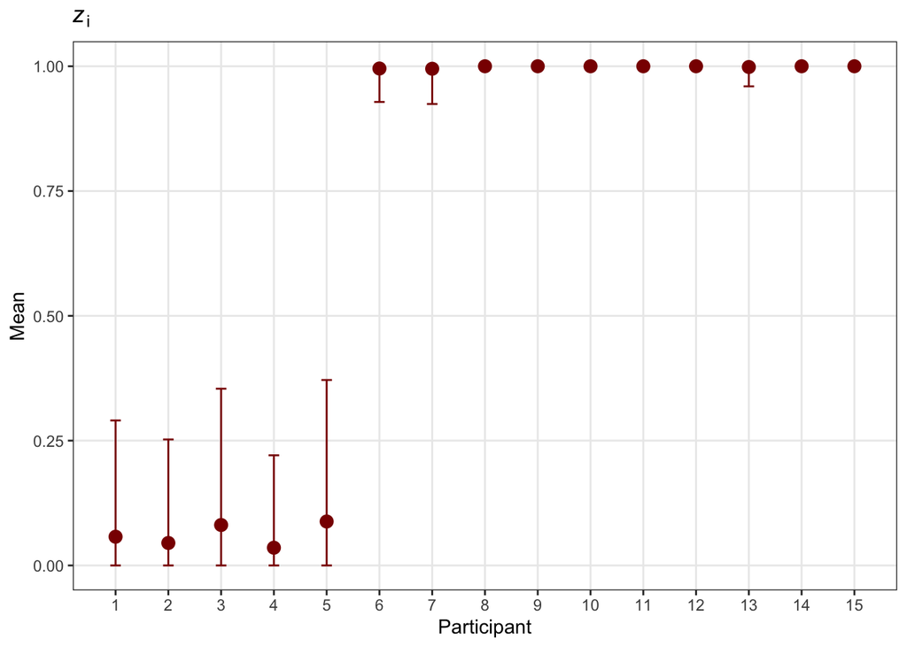

```r
# p1 %>% select(starts_with("z")) %>%
#   pivot_longer(cols = starts_with("z"),
#                names_to = "SID", values_to = "Value") %>%
#   separate(col = 'SID', c(NA, "Participant")) %>%
#   mutate(Participant = as.numeric(Participant)) %>%
#   ggplot(aes(x = Participant, y = Value)) +
#   geom_jitter(color = "darkred", width = 0.2, height = 0, alpha = 1/50) +
#   scale_x_continuous(breaks = seq(1, 15, by = 1)) +
#   labs(title = expression(paste(italic(z)[i]))) +
#   theme_bw() +
#   theme(panel.grid.minor = element_blank())

p1 %>% pivot_longer(cols = starts_with("z"),
                    names_to = "SID",
                    values_to = "Value") %>%
  group_by(SID) %>%
  summarise(Mean = mean(Value),
            SD = sd(Value)) %>%
  ungroup() %>%
  separate(col = 'SID', c(NA, "Participant")) %>%
  mutate(Participant = as.numeric(Participant)) %>%
  ggplot(aes(x = Participant, y = Mean)) +
  geom_point(color = "darkred", size = 3) +
  geom_errorbar(aes(ymin=ifelse(Mean-SD<0,0,Mean-SD),
                    ymax=ifelse(Mean+SD>1,1,Mean+SD)), width=.2, color = "darkred") +
  scale_x_continuous(breaks = seq(1, 15, by = 1)) +
  labs(title = expression(paste(italic(z)[i]))) +
  theme_bw() +
  theme(panel.grid.minor = element_blank())
```

## 2.4 phi

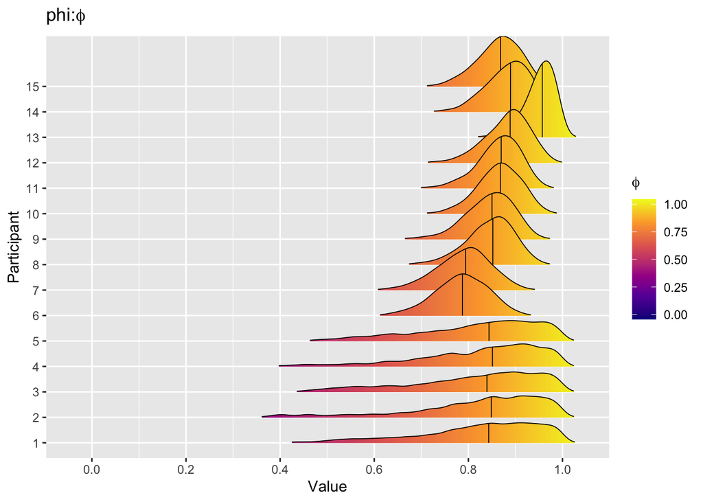

```r
p1 %>% select(starts_with("phi")) %>%
  pivot_longer(cols = starts_with("phi"),
               names_to = "SID", values_to = "Value") %>%
  separate(col = 'SID', c(NA, "Participant")) %>%
  mutate(Participant = as.numeric(Participant)) %>%
  ggplot(aes(y = Participant, x = Value, fill = stat(x))) +
  geom_density_ridges_gradient(aes(y = as.factor(Participant)),
                               stat = "density_ridges",
                               scale = 3, linewidth = 0.3, rel_min_height = 0.01,
                               quantile_lines = TRUE, quantiles = 0.5) +
  expand_limits(x=c(0,1)) +
  # scale_y_discrete(limits = rev) +
  scale_x_continuous(breaks = seq(0, 1, by = 0.2)) +
  scale_fill_viridis_c(name = expression(phi), option = "C") +
  labs(title = expression(paste('phi:', phi)))
```

## 2.5 theta

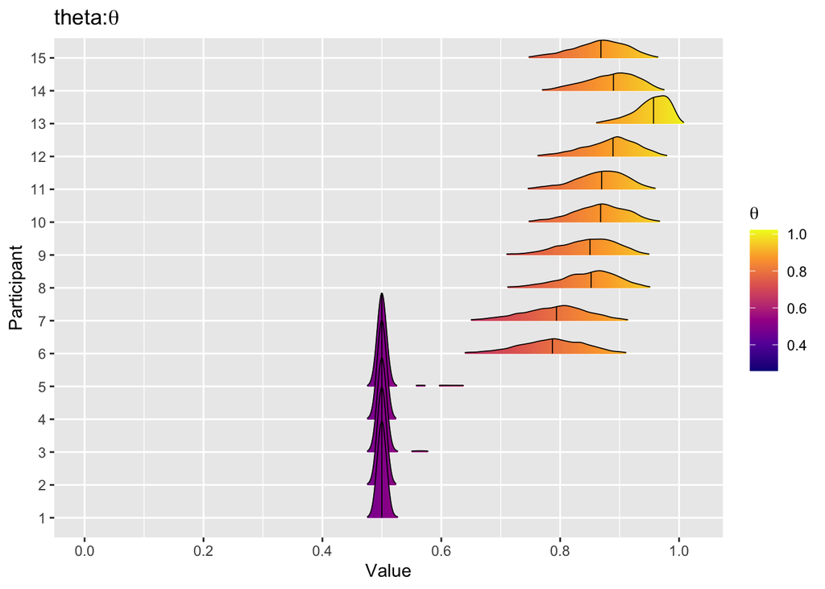

```r
p1 %>% select(starts_with("theta")) %>%
  pivot_longer(cols = starts_with("theta"),
               names_to = "SID", values_to = "Value") %>%
  separate(col = 'SID', c(NA, "Participant")) %>%
  mutate(Participant = as.numeric(Participant)) %>%
  ggplot(aes(y = Participant, x = Value, fill = stat(x))) +
  geom_density_ridges_gradient(aes(y = as.factor(Participant)),
                               stat = "density_ridges",
                               scale = 3, linewidth = 0.3, rel_min_height = 0.01,
                               quantile_lines = TRUE, quantiles = 0.5) +
  expand_limits(x=c(0,1)) +
  # scale_y_discrete(limits = rev) +
  scale_x_continuous(breaks = seq(0, 1, by = 0.2)) +
  scale_fill_viridis_c(name = expression(theta), option = "C") +
  labs(title = expression(paste('theta:', theta)))
```

## 2.6 mu

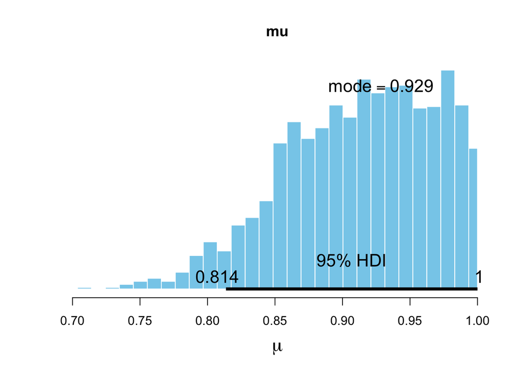

```r
plot_post(p1$mu, main = "mu", xlab = expression(mu), quietly = TRUE)
```

## 2.7 sigma

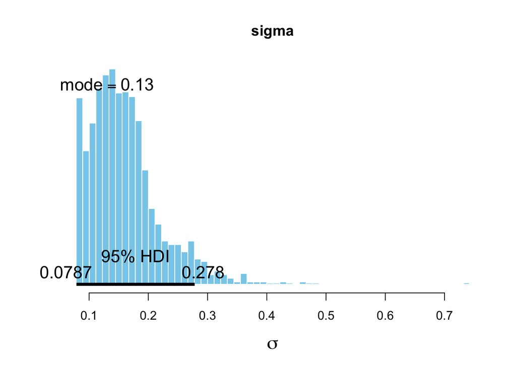

```r
plot_post(p1$sigma, main = "sigma", xlab = expression(sigma), quietly = TRUE)
```

## 2.8 predictive distribution

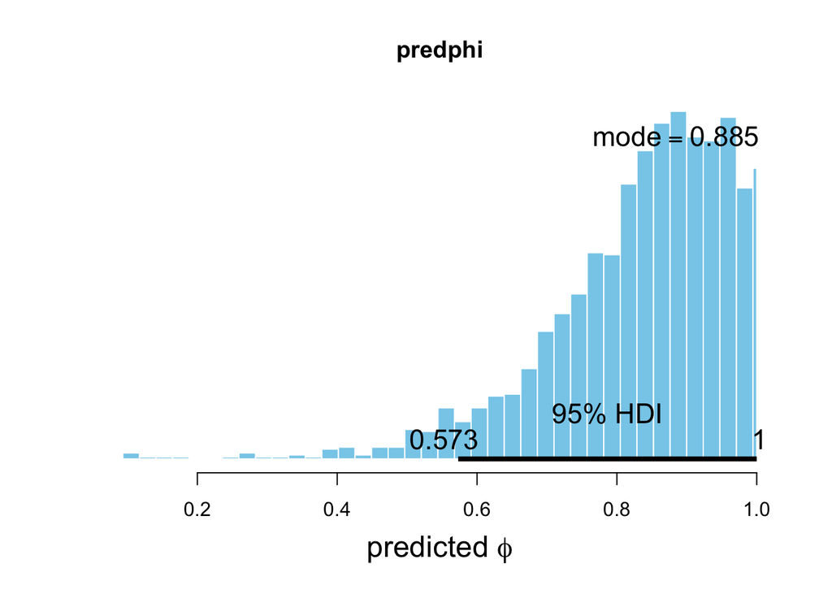

```r
plot_post(p1$predphi, main = "predphi", xlab = expression(paste('predicted ', phi)), quietly = TRUE)
```

*Prior*와 *posterior*의 *predictive distribution*을 겹쳐서 그려보자.

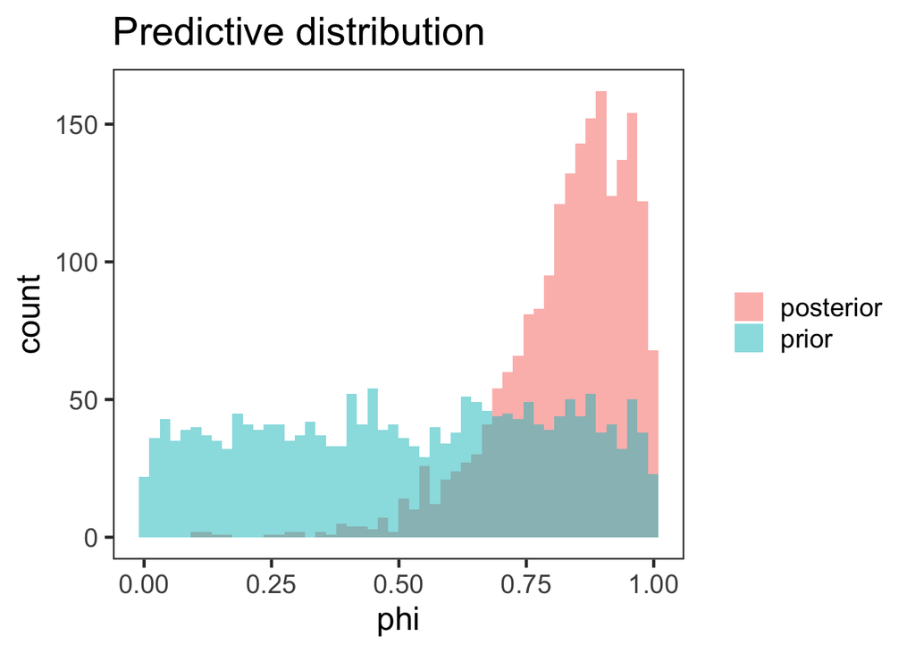

```r
p1 %>% select(predphi, priorpredphi) %>%
  rename(prior = priorpredphi, posterior = predphi) %>%
  pivot_longer(cols = everything(), names_to = "prediction", values_to = "phi") %>%
  ggplot(aes(x = phi, fill = prediction)) +
  geom_histogram(position = "identity", alpha = 0.5, bins = 50) +
  labs(title = "Predictive distribution") +
  theme_bw(base_size = 18) +
  theme(panel.grid.major = element_blank(),
        panel.grid.minor = element_blank(),
        legend.title = element_blank())
```

# 3 Exercise 6.2.1

40 문제 중 28개 맞은 사람 추가하자.

```r
k <- c(21,17,21,18,22,31,31,34,34,35,35,36,39,36,35, 28)
p <- length(k) #number of people
n <- 40 # number of questions

data <- list("p", "k", "n") # to be passed on to JAGS
myinits <-  list(
  list(mu = 0.75, lambda = 1, z = round(runif(p)),
       muprior = 0.75, lambdaprior = 1)) # Initial group assignment


samples2 <- jags(data, inits=myinits, parameters,
                model.file = textConnection(model_text),
                n.chains=1, n.iter=2000,
                n.burnin=1, n.thin=1, DIC=T)
```

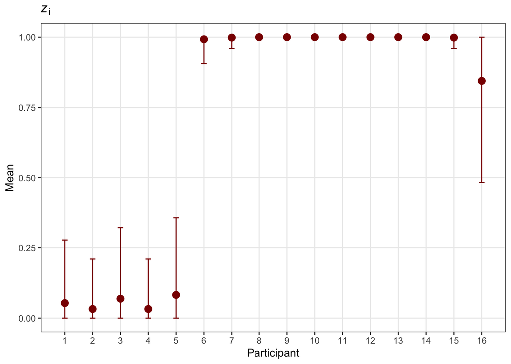

```r
p2 <- posterior(samples2)

# z
p2 %>% pivot_longer(cols = starts_with("z"),
                    names_to = "SID",
                    values_to = "Value") %>%
  group_by(SID) %>%
  summarise(Mean = mean(Value),
            SD = sd(Value)) %>%
  ungroup() %>%
  separate(col = 'SID', c(NA, "Participant")) %>%
  mutate(Participant = as.numeric(Participant)) %>%
  ggplot(aes(x = Participant, y = Mean)) +
  geom_point(color = "darkred", size = 3) +
  geom_errorbar(aes(ymin=ifelse(Mean-SD<0,0,Mean-SD),
                    ymax=ifelse(Mean+SD>1,1,Mean+SD)), width=.2, color = "darkred") +
  scale_x_continuous(breaks = seq(1, 16, by = 1)) +
  labs(title = expression(paste(italic(z)[i]))) +
  theme_bw() +
  theme(panel.grid.minor = element_blank())
```

# 4 Session Info

```r
sessionInfo()
R version 4.2.3 (2023-03-15)
Platform: aarch64-apple-darwin20 (64-bit)
Running under: macOS Ventura 13.3.1

Matrix products: default
BLAS:   /Library/Frameworks/R.framework/Versions/4.2-arm64/Resources/lib/libRblas.0.dylib
LAPACK: /Library/Frameworks/R.framework/Versions/4.2-arm64/Resources/lib/libRlapack.dylib

locale:
[1] en_US.UTF-8/en_US.UTF-8/en_US.UTF-8/C/en_US.UTF-8/en_US.UTF-8

attached base packages:
[1] stats     graphics  grDevices utils     datasets  methods   base

other attached packages:
 [1] ggdist_3.2.1      CalvinBayes_0.2.6 bayesplot_1.10.0  ggformula_0.10.2
 [5] ggridges_0.5.5    scales_1.2.1      ggstance_0.3.6    klippy_0.0.0.9500
 [9] R2jags_0.7-1      rjags_4-13        coda_0.19-4       psych_2.3.3
[13] cowplot_1.1.1     lubridate_1.9.2   forcats_1.0.0     stringr_1.5.0
[17] dplyr_1.1.1       purrr_1.0.1       readr_2.1.4       tidyr_1.3.0
[21] tibble_3.2.1      ggplot2_3.4.2     tidyverse_2.0.0   pacman_0.5.1

loaded via a namespace (and not attached):
  [1] backports_1.4.1      plyr_1.8.8           igraph_1.4.1
  [4] crosstalk_1.2.0      rstantools_2.3.1     inline_0.3.19
  [7] digest_0.6.31        htmltools_0.5.5      magick_2.7.4
 [10] fansi_1.0.4          magrittr_2.0.3       checkmate_2.1.0
 [13] tzdb_0.3.0           mosaicCore_0.9.2.1   brms_2.19.0
 [16] RcppParallel_5.1.7   matrixStats_0.63.0   xts_0.13.0
 [19] timechange_0.2.0     prettyunits_1.1.1    colorspace_2.1-0
 [22] haven_2.5.2          xfun_0.38            callr_3.7.3
 [25] crayon_1.5.2         jsonlite_1.8.4       zoo_1.8-11
 [28] glue_1.6.2           polyclip_1.10-4      gtable_0.3.3
 [31] distributional_0.3.2 pkgbuild_1.4.0       rstan_2.21.8
 [34] abind_1.4-5          mvtnorm_1.1-3        DBI_1.1.3
 [37] miniUI_0.1.1.1       Rcpp_1.0.10          viridisLite_0.4.1
 [40] xtable_1.8-4         stats4_4.2.3         StanHeaders_2.21.0-7
 [43] DT_0.27              htmlwidgets_1.6.2    threejs_0.3.3
 [46] posterior_1.4.1      ellipsis_0.3.2       pkgconfig_2.0.3
 [49] loo_2.6.0            farver_2.1.1         sass_0.4.5
 [52] utf8_1.2.3           labeling_0.4.2       tidyselect_1.2.0
 [55] rlang_1.1.0          reshape2_1.4.4       later_1.3.0
 [58] munsell_0.5.0        tools_4.2.3          cachem_1.0.7
 [61] cli_3.6.1            generics_0.1.3       broom_1.0.4
 [64] evaluate_0.20        fastmap_1.1.1        yaml_2.3.7
 [67] processx_3.8.0       knitr_1.42           tidygraph_1.2.3
 [70] nlme_3.1-162         mime_0.12            compiler_4.2.3
 [73] shinythemes_1.2.0    rstudioapi_0.14      tweenr_2.0.2
 [76] bslib_0.4.2          stringi_1.7.12       highr_0.10
 [79] ps_1.7.4             Brobdingnag_1.2-9    lattice_0.21-8
 [82] Matrix_1.5-4         markdown_1.6         shinyjs_2.1.0
 [85] tensorA_0.36.2       vctrs_0.6.1          pillar_1.9.0
 [88] lifecycle_1.0.3      jquerylib_0.1.4      bridgesampling_1.1-2
 [91] httpuv_1.6.9         R2WinBUGS_2.1-21     R6_2.5.1
 [94] promises_1.2.0.1     gridExtra_2.3        codetools_0.2-19
 [97] boot_1.3-28.1        colourpicker_1.2.0   MASS_7.3-58.3
[100] gtools_3.9.4         assertthat_0.2.1     withr_2.5.0
[103] ggdag_0.2.8          shinystan_2.6.0      mnormt_2.1.1
[106] parallel_4.2.3       hms_1.1.3            grid_4.2.3
[109] labelled_2.10.0      rmarkdown_2.21       ggforce_0.4.1
[112] shiny_1.7.4          base64enc_0.1-3      dygraphs_1.1.1.6
```